# Análisis de uso y reciclaje de botellas en la universidad

## Introducción

Este análisis explora los hábitos de uso, reciclaje y reutilización de botellas entre estudiantes universitarios. Los datos fueron recopilados mediante encuesta durante marzo y abril de 2025.

## Distribución demográfica

### Participantes por facultad

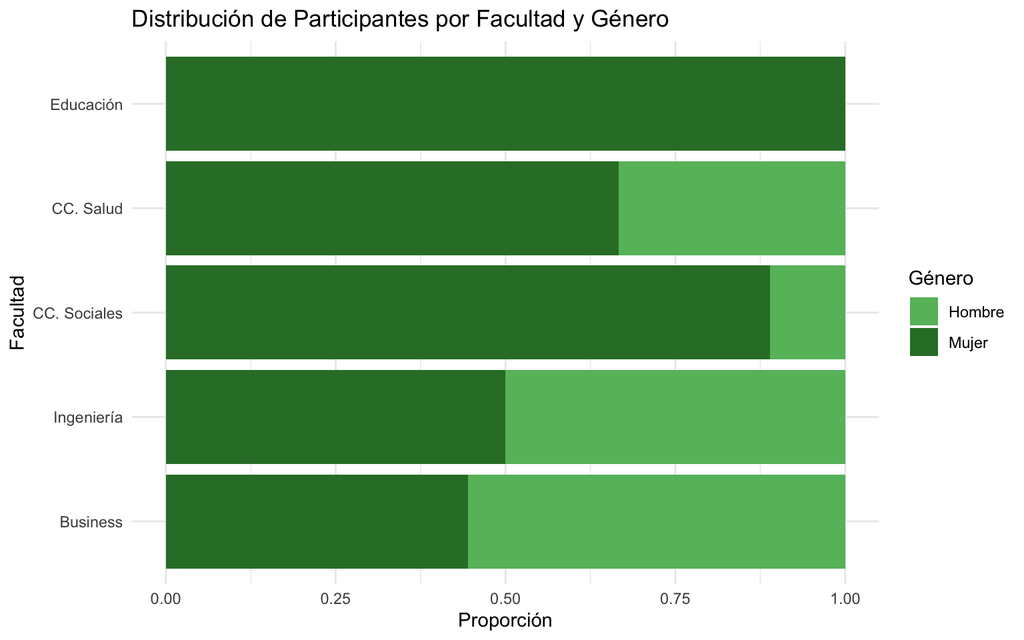

```r
# Crear un gráfico de mosaico para representar la relación entre Facultad y Género
ggplot(datos) +
  geom_bar(aes(x = Facultad, fill = Genero), position = "fill") +
  coord_flip() +
  labs(title = "Distribución de Participantes por Facultad y Género",
       x = "Facultad",
       y = "Proporción",
       fill = "Género") +
  theme_minimal() +
  scale_fill_manual(values = c("Hombre" = verde_medio, "Mujer" = verde_oscuro))
```

El análisis muestra que las mujeres representan la mayoría en casi todas las facultades, especialmente en áreas como **Ciencias Sociales y Humanas** , **Educación y Deporte** , y **Ciencias de la Salud** , mientras que en facultades como **Ingeniería** y **Deusto Business School** la distribución entre hombres y mujeres es más equilibrada. Este patrón sugiere una mayor participación femenina en disciplinas relacionadas con ciencias sociales y humanidades, lo que podría influir en el diseño de estrategias específicas para involucrar a ambos géneros en proyectos de reciclaje. Por ejemplo, las iniciativas podrían adaptarse para fomentar la participación masculina en áreas donde su presencia es menor pero significativa.

### Rango de edad

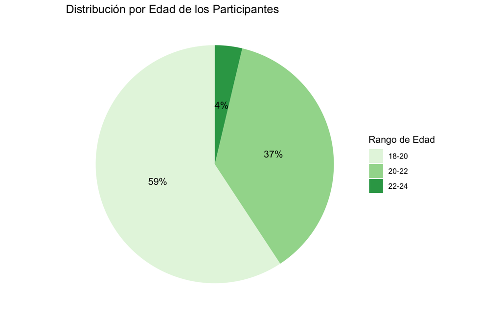

```r
# Crear un gráfico de waffle para mostrar la distribución por edad
edad_counts <- table(datos$Edad)
edad_percent <- round(100 * edad_counts / sum(edad_counts))

edad_df <- data.frame(
  edad = names(edad_counts),
  count = as.numeric(edad_counts),
  percent = as.numeric(edad_percent)
)

ggplot(edad_df, aes(x = "", y = count, fill = edad)) +
  geom_bar(stat = "identity", width = 1) +
  coord_polar("y") +
  scale_fill_brewer(palette = "Greens") +
  labs(title = "Distribución por Edad de los Participantes",
       fill = "Rango de Edad") +
  theme_void() +
  geom_text(aes(label = paste0(percent, "%")),
            position = position_stack(vjust = 0.5))
```

## Hábitos de consumo de botellas

### Origen de las botellas

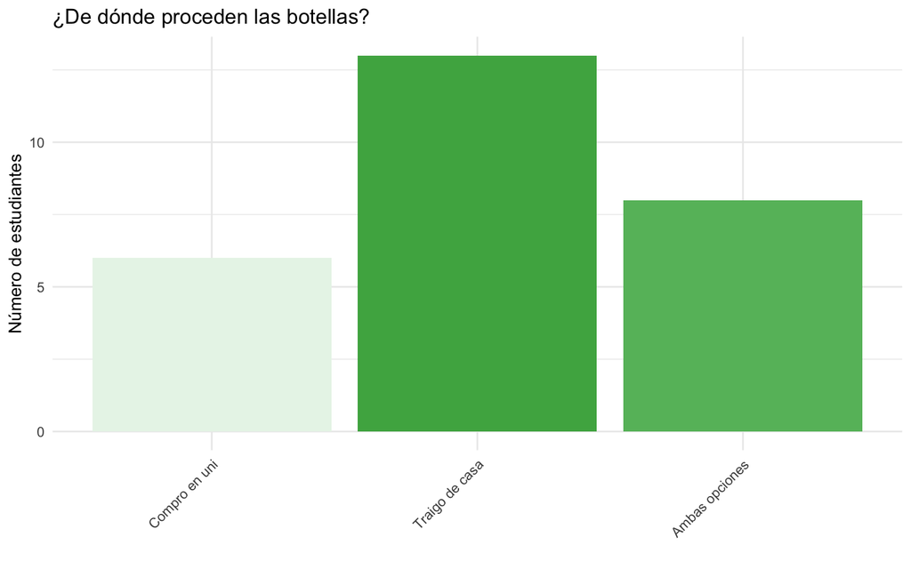

```r
# Gráfico de barras para origen de botellas con tonos verdes
ggplot(datos, aes(x = Botella, fill = Botella)) +
  geom_bar() +
  theme_minimal() +
  labs(title = "¿De dónde proceden las botellas?",
       x = "",
       y = "Número de estudiantes") +
  scale_fill_manual(values = c("Compro en uni" = verde_claro,
                              "Traigo de casa" = verde_medio_oscuro,
                              "Ambas opciones" = verde_medio)) +
  theme(legend.position = "none",
        axis.text.x = element_text(angle = 45, hjust = 1))
```

### Hábitos de reutilización

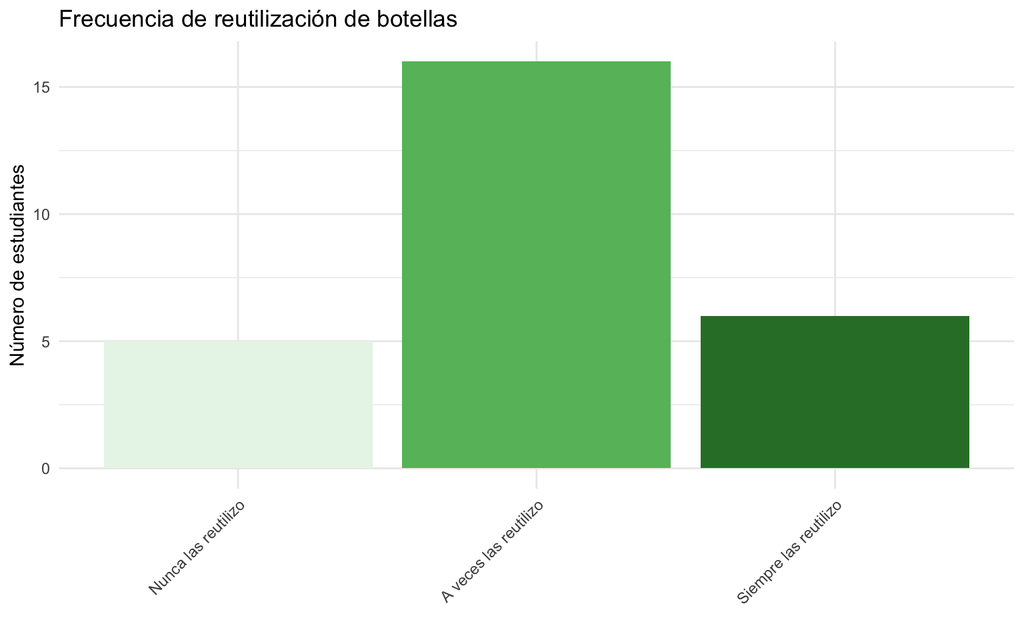

```r
# Gráfico de barras para reutilización con tonos verdes
ggplot(datos, aes(x = HacerConBotellas, fill = HacerConBotellas)) +
  geom_bar() +
  theme_minimal() +
  labs(title = "Frecuencia de reutilización de botellas",
       x = "",
       y = "Número de estudiantes") +
  scale_fill_manual(values = c("Nunca las reutilizo" = verde_claro,
                               "A veces las reutilizo" = verde_medio,
                               "Siempre las reutilizo" = verde_oscuro)) +
  theme(legend.position = "none",
        axis.text.x = element_text(angle = 45, hjust = 1))
```

La **mayoría** de los estudiantes *reutilizan las botellas al menos ocasionalmente*, con un predominio de aquellos que lo hacen “a veces”. Relativamente pocos estudiantes afirman no reutilizar nunca las botellas, lo que indica una predisposición general favorable hacia comportamientos sostenibles. Sin embargo, el hecho de que la categoría “a veces” sea la más común sugiere que existe margen para mejorar y fomentar una reutilización más consistente. Las campañas educativas podrían centrarse en convertir estos hábitos ocasionales en rutinas permanentes.

## Preocupación por el reciclaje

### Nivel de preocupación

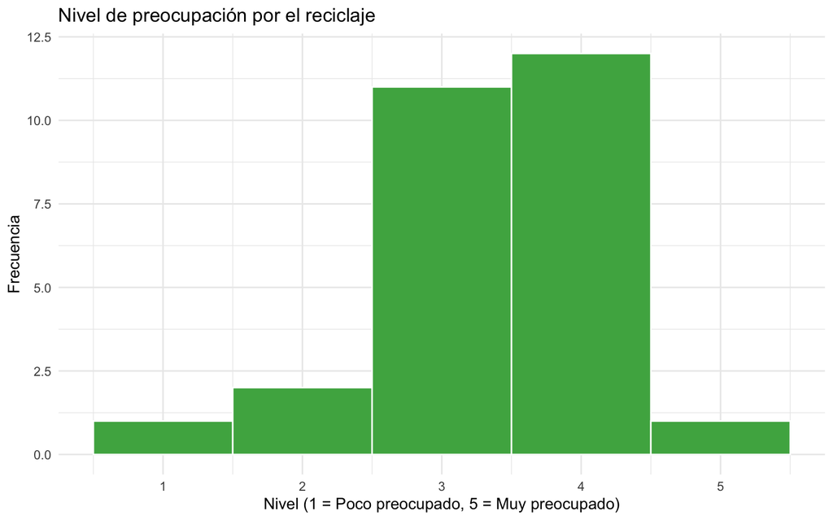

```r
# Histograma de preocupación con tonos verdes
ggplot(datos, aes(x = PreocupaciónReciclaje)) +
  geom_histogram(binwidth = 1, fill = verde_medio_oscuro, color = "white") +
  theme_minimal() +
  labs(title = "Nivel de preocupación por el reciclaje",
       x = "Nivel (1 = Poco preocupado, 5 = Muy preocupado)",
       y = "Frecuencia") +
  scale_x_continuous(breaks = 1:5)
```

Este histograma muestra que la *mayoría de los estudiantes* *expresan* un **nivel de preocupación medio-alto (3-4) por el reciclaje**, con *pocas respuestas en los extremos*. El pico en el nivel 4 indica una conciencia generalizada sobre la importancia del reciclaje, pero no necesariamente al nivel más alto de preocupación. Esto sugiere que los estudiantes están sensibilizados con el tema, aunque podría haber espacio para incrementar la concienciación sobre la urgencia de los problemas ambientales relacionados con el plástico y fomentar un compromiso más profundo.

### Preocupación por facultad

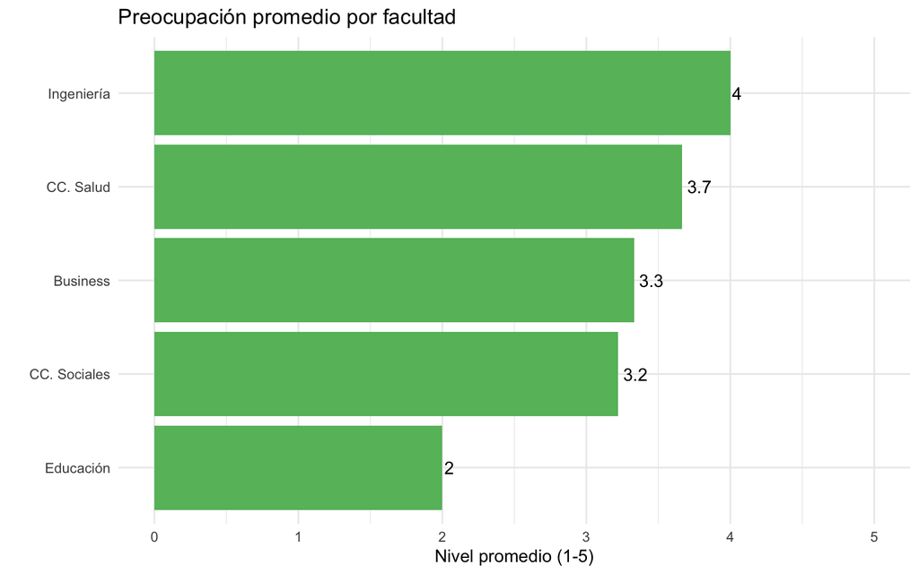

```r
# Promedio de preocupación por facultad con tonos verdes
datos_promedio <- datos %>%
  group_by(Facultad) %>%
  summarise(Preocupación = mean(PreocupaciónReciclaje, na.rm = TRUE)) %>%
  arrange(desc(Preocupación))

ggplot(datos_promedio, aes(x = reorder(Facultad, Preocupación), y = Preocupación)) +
  geom_col(fill = verde_medio) +
  theme_minimal() +
  labs(title = "Preocupación promedio por facultad",
       x = "",
       y = "Nivel promedio (1-5)") +
  coord_flip() +
  geom_text(aes(label = round(Preocupación, 1)), hjust = -0.2) +
  ylim(0, 5)
```

Este gráfico *revela diferencias interesantes* e*n los niveles de preocupación por el reciclaje entre las distintas facultades*. **Ingeniería y CC. Salud** muestran los **niveles más altos**, mientras que CC. Sociales y Bussiness presentan valores intermedios. Estas diferencias podrían reflejar variaciones en la formación académica, la cultura de cada facultad o las iniciativas específicas de sensibilización ambiental implementadas en cada una. Esta información es útil para adaptar las campañas de concienciación a las necesidades específicas de cada facultad, reforzando especialmente aquellas con niveles más bajos de preocupación.

## Relación entre origen y reutilización

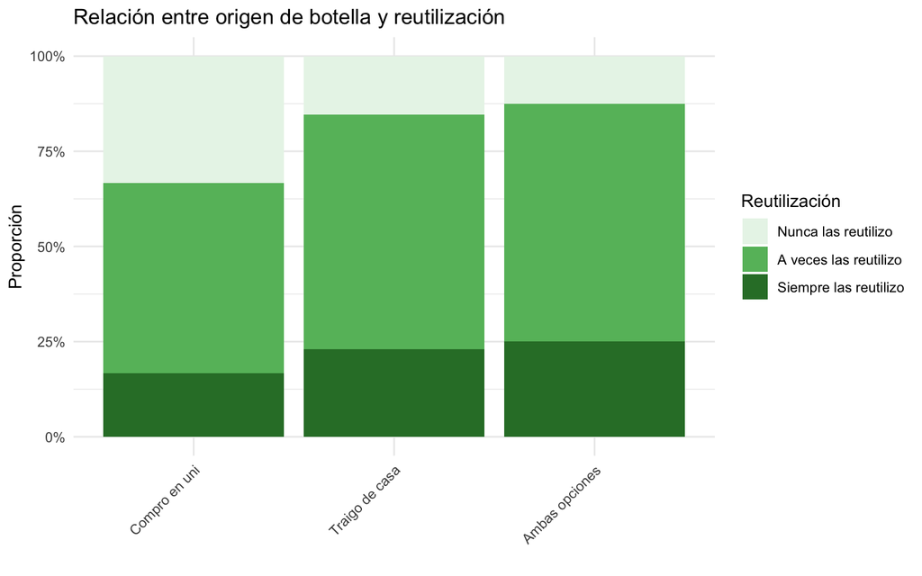

```r
# Gráfico de mosaico con tonos verdes
ggplot(datos, aes(x = Botella, fill = HacerConBotellas)) +
  geom_bar(position = "fill") +
  theme_minimal() +
  labs(title = "Relación entre origen de botella y reutilización",
       x = "",
       y = "Proporción",
       fill = "Reutilización") +
  scale_fill_manual(values = c("Nunca las reutilizo" = verde_claro,
                               "A veces las reutilizo" = verde_medio,
                               "Siempre las reutilizo" = verde_oscuro)) +
  scale_y_continuous(labels = percent_format()) +
  theme(axis.text.x = element_text(angle = 45, hjust = 1))
```

## Evaluación de iniciativas universitarias

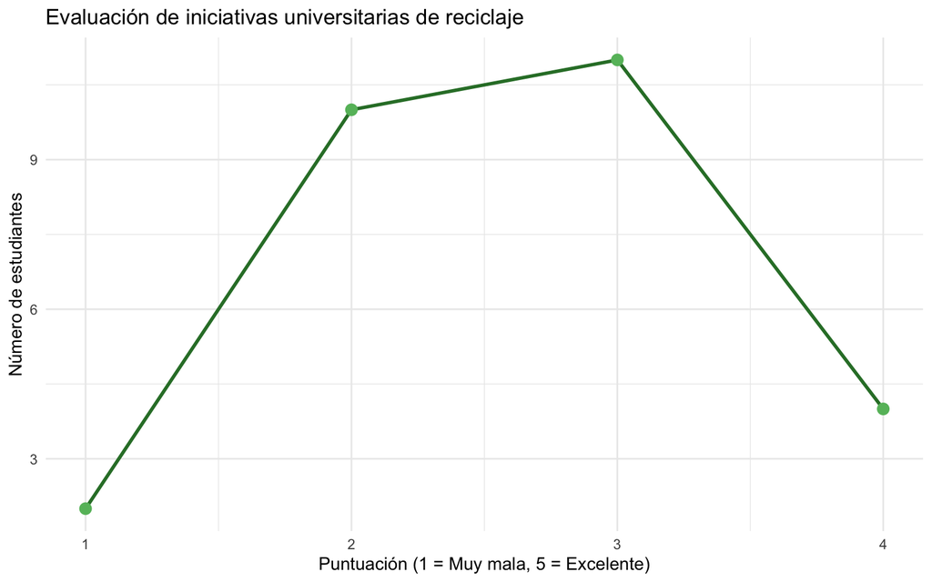

```r
# Gráfico de líneas para evaluación con tonos verdes
datos_eval <- datos %>%
  group_by(Evaluación) %>%
  summarise(Cantidad = n())

ggplot(datos_eval, aes(x = Evaluación, y = Cantidad, group = 1)) +
  geom_line(size = 1, color = verde_oscuro) +
  geom_point(size = 3, color = verde_medio) +
  theme_minimal() +
  labs(title = "Evaluación de iniciativas universitarias de reciclaje",
       x = "Puntuación (1 = Muy mala, 5 = Excelente)",
       y = "Número de estudiantes") +
  scale_x_continuous(breaks = 1:5)
```

La evaluación de las iniciativas universitarias de reciclaje muestra una distribución con pico en el nivel 3 (regular), y menor frecuencia en los extremos. **Esto indica que la mayoría de estudiantes perciben las iniciativas como moderadamente satisfactorias,** *pero con amplio margen de mejora*. La caída en las evaluaciones más altas (4-5) sugiere que **pocas personas consideran excelentes las iniciativas actuales**. La universidad debería analizar qué aspectos específicos de sus programas de reciclaje podrían mejorarse para aumentar la satisfacción y efectividad percibida por los estudiantes.

## Disposición a participar

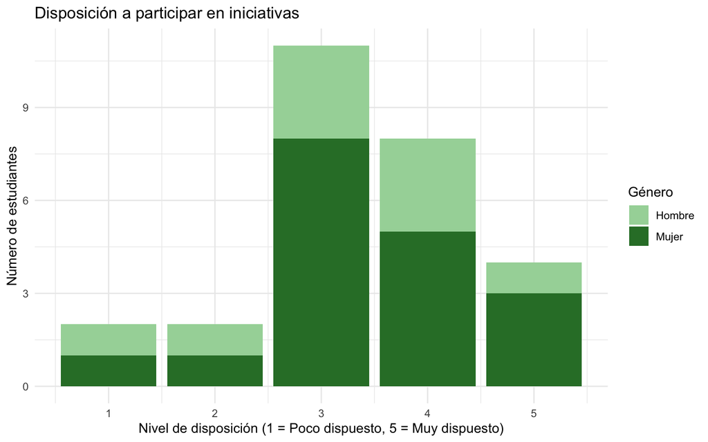

```r
# Gráfico de barras apiladas por género con tonos verdes
ggplot(datos, aes(x = DispuestoParticipar, fill = Genero)) +
  geom_bar(position = "stack") +
  theme_minimal() +
  labs(title = "Disposición a participar en iniciativas",
       x = "Nivel de disposición (1 = Poco dispuesto, 5 = Muy dispuesto)",
       y = "Número de estudiantes",
       fill = "Género") +
  scale_fill_manual(values = c("Hombre" = verde_medio_claro, "Mujer" = verde_oscuro)) +
  scale_x_continuous(breaks = 1:5)
```

Este gráfico **muestra una tendencia favorable hacia la participación en iniciativas de reciclaje,** con más **respuestas concentradas en los niveles 3-5.** *Las mujeres parecen mostrar mayor disposición a participar que los hombres,* especialmente en los niveles más altos. Esta diferencia de género podría ser relevante para el diseño de campañas y programas de reciclaje, sugiriendo la necesidad de enfoques específicos para incrementar la participación masculina. En general, el nivel moderado-alto de disposición indica que existe un potencial significativo para involucrar a los estudiantes en nuevas iniciativas si éstas se diseñan adecuadamente.

## Comparativa por edad

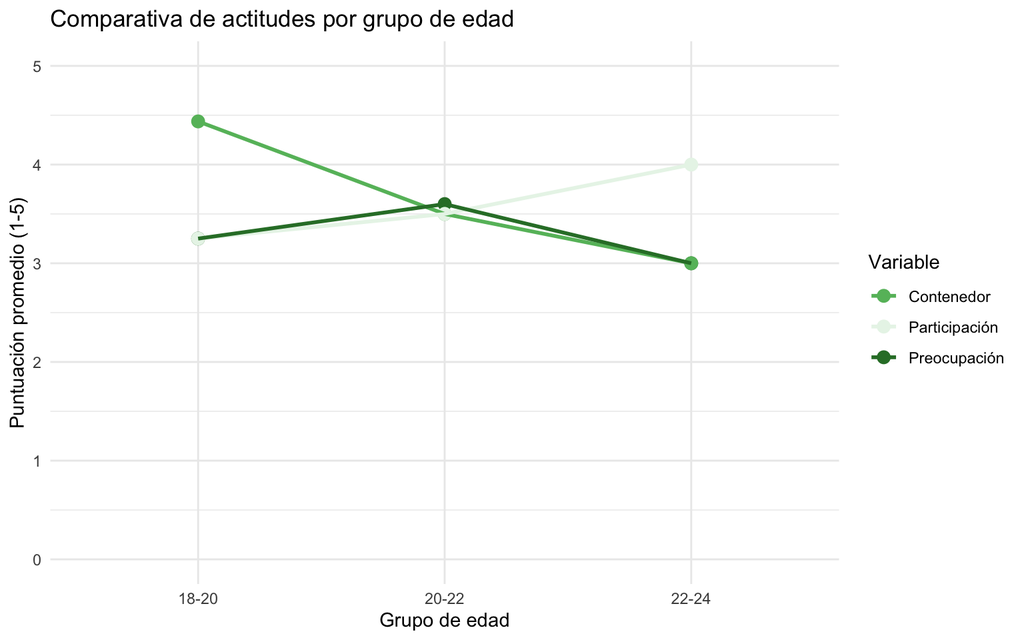

```r
# Gráfico de puntos con líneas para comparar variables por edad con tonos verdes
datos_edad <- datos %>%
  group_by(Edad) %>%
  summarise(
    Preocupación = mean(PreocupaciónReciclaje, na.rm = TRUE),
    Contenedor = mean(respectivoContenedor, na.rm = TRUE),
    Participación = mean(DispuestoParticipar, na.rm = TRUE)
  ) %>%
  pivot_longer(cols = c(Preocupación, Contenedor, Participación),
               names_to = "Variable", values_to = "Valor")

ggplot(datos_edad, aes(x = Edad, y = Valor, color = Variable, group = Variable)) +
  geom_point(size = 3) +
  geom_line(size = 1) +
  theme_minimal() +
  labs(title = "Comparativa de actitudes por grupo de edad",
       x = "Grupo de edad",
       y = "Puntuación promedio (1-5)",
       color = "Variable") +
  scale_color_manual(values = c("Preocupación" = verde_oscuro,
                                "Contenedor" = verde_medio,
                                "Participación" = verde_claro)) +
  ylim(0, 5)
```

## Ideas propuestas más comunes

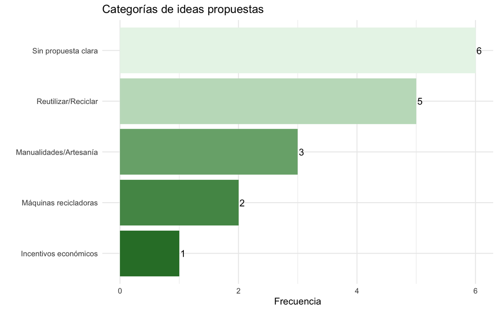

```r
# Categorización de ideas con tonos verdes
ideas_categorias <- c(
  "Reutilizar/Reciclar" = sum(grepl("reutilizar|reciclar|reutilización",
                                    datos$Ideas, ignore.case = TRUE)),
  "Manualidades/Artesanía" = sum(grepl("manualidades|macetas|florero",
                                       datos$Ideas, ignore.case = TRUE)),
  "Incentivos económicos" = sum(grepl("vales|tickets|dinero",
                                      datos$Ideas, ignore.case = TRUE)),
  "Máquinas recicladoras" = sum(grepl("máquina|compactar",
                                      datos$Ideas, ignore.case = TRUE)),
  "Sin propuesta clara" = sum(grepl("no se|nose|nada",
                                   datos$Ideas, ignore.case = TRUE))
)

ideas_df <- data.frame(
  Categoría = names(ideas_categorias),
  Frecuencia = unname(ideas_categorias)
)

# Ordenar por frecuencia
ideas_df <- ideas_df[order(-ideas_df$Frecuencia),]

# Asignar colores verdes según la frecuencia
num_categorias <- nrow(ideas_df)
verde_secuencial <- colorRampPalette(c(verde_oscuro, verde_claro))(num_categorias)

ggplot(ideas_df, aes(x = reorder(Categoría, Frecuencia), y = Frecuencia, fill = Frecuencia)) +
  geom_col() +
  coord_flip() +
  theme_minimal() +
  labs(title = "Categorías de ideas propuestas",
       x = "",
       y = "Frecuencia") +
  scale_fill_gradientn(colors = verde_secuencial) +
  theme(legend.position = "none") +
  geom_text(aes(label = Frecuencia), hjust = -0.2)
```